### Compare the flipper length of penguins using statistical tests

First, create subsets of the flipper length of all species as vectors:

```r
library(palmerpenguins)
library(tidyverse)
adelie <- filter(penguins, species == "Adelie")$flipper_length_mm
gentoo <- filter(penguins, species == "Gentoo")$flipper_length_mm
chinstrap <- filter(penguins, species == "Chinstrap")$flipper_length_mm
```

#### Step 1: Test all groups for normality

**With Shapiro-Wilk**

The Shapiro-Wilk test suggests that Adelie and Chinstrap are normally distributed, but Gentoo is not.

```r
shapiro.test(adelie)
```

```
##
##  Shapiro-Wilk normality test
##
## data:  adelie
## W = 0.99339, p-value = 0.72
```

```r
shapiro.test(gentoo)
```

```
##
##  Shapiro-Wilk normality test
##
## data:  gentoo
## W = 0.96219, p-value = 0.00162
```

```r
shapiro.test(chinstrap)
```

```
##
##  Shapiro-Wilk normality test
##
## data:  chinstrap
## W = 0.98891, p-value = 0.8106
```

**With QQ-plots**

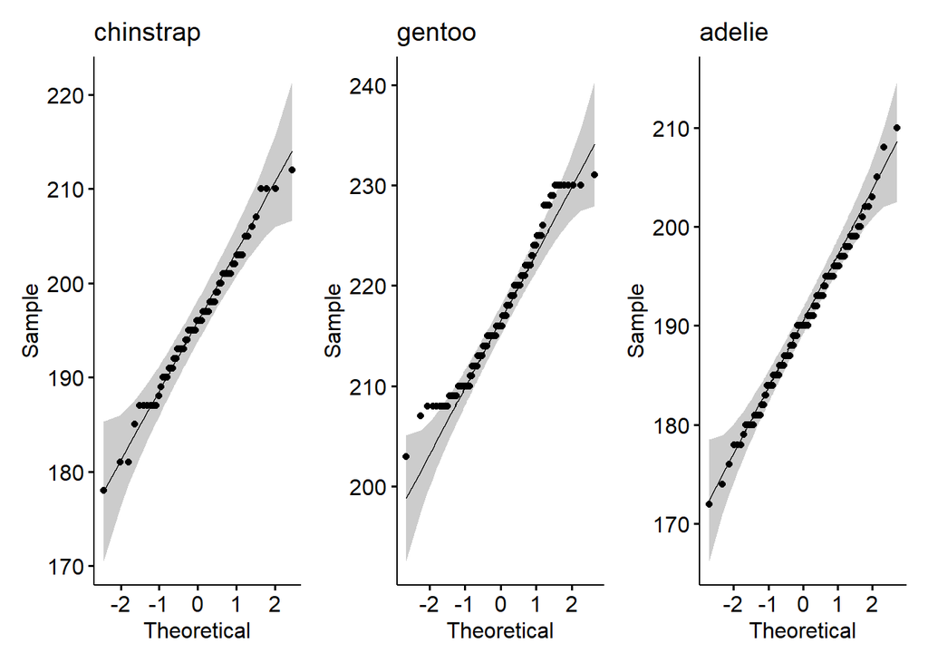

```r
library(patchwork) # using patchwork to combine multiple plots into one
ch <- ggpubr::ggqqplot(chinstrap) + labs(title = "chinstrap")
ad <- ggpubr::ggqqplot(adelie) + labs(title = "adelie")
ge <- ggpubr::ggqqplot(gentoo) + labs(title = "gentoo")

ch + ge + ad
```

#### Compare Chinstrap vs. Adelie

Both are normally distributed, so we can compare variances for Chinstrap and Adelie penguins:

```r
var.test(chinstrap, adelie)
```

```
##
##  F test to compare two variances
##
## data:  chinstrap and adelie
## F = 1.1894, num df = 67, denom df = 150, p-value = 0.3854
## alternative hypothesis: true ratio of variances is not equal to 1
## 95 percent confidence interval:
##  0.8022092 1.8217141
## sample estimates:
## ratio of variances
##           1.189396
```

This indicates that the variances do not differ between Chinstrap and Adelie penguins. Therefore, we can use a t-test to compare mean flipper length:

```r
t.test(chinstrap, adelie)
```

```
##
##  Welch Two Sample t-test
##
## data:  chinstrap and adelie
## t = 5.7804, df = 119.68, p-value = 6.049e-08
## alternative hypothesis: true difference in means is not equal to 0
## 95 percent confidence interval:
##  3.859244 7.880530
## sample estimates:
## mean of x mean of y
##  195.8235  189.9536
```

The t-test suggests, that the mean flipper length differs between Chinstrap and Adelie penguins.

#### Compare Chinstrap vs. Gentoo

Gentoo is not normally distributed, so we can use a Wilcoxon-rank-sum test to compare means:

```r
wilcox.test(chinstrap, gentoo)
```

```
##
##  Wilcoxon rank sum test with continuity correction
##
## data:  chinstrap and gentoo
## W = 92, p-value < 2.2e-16
## alternative hypothesis: true location shift is not equal to 0
```

The Wilcoxon tests suggests that the flipper lengths differ between Chinstrap and Gentoo penguins.

#### Compare Adelie vs. Gentoo

Gentoo is not normally distributed, so we can use a Wilcoxon-rank-sum test to compare means:

```r
wilcox.test(adelie, gentoo)
```

```
##
##  Wilcoxon rank sum test with continuity correction
##
## data:  adelie and gentoo
## W = 26, p-value < 2.2e-16
## alternative hypothesis: true location shift is not equal to 0
```

The Wilcoxon tests suggests that the flipper lengths differ between Adelie and Gentoo penguins.

#### Visual comparison

The boxplot supports the findings of the statistical tests. Notches do not overlap.

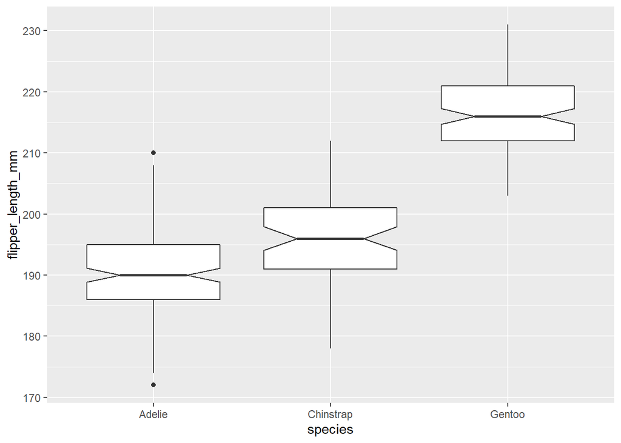

```r
penguins %>%
  ggplot(aes(x = species, y = flipper_length_mm)) +
  geom_boxplot(notch = TRUE)
```

Similarly the standard errors of the means do not overlap between the species.

```
## No summary function supplied, defaulting to `mean_se()`
```

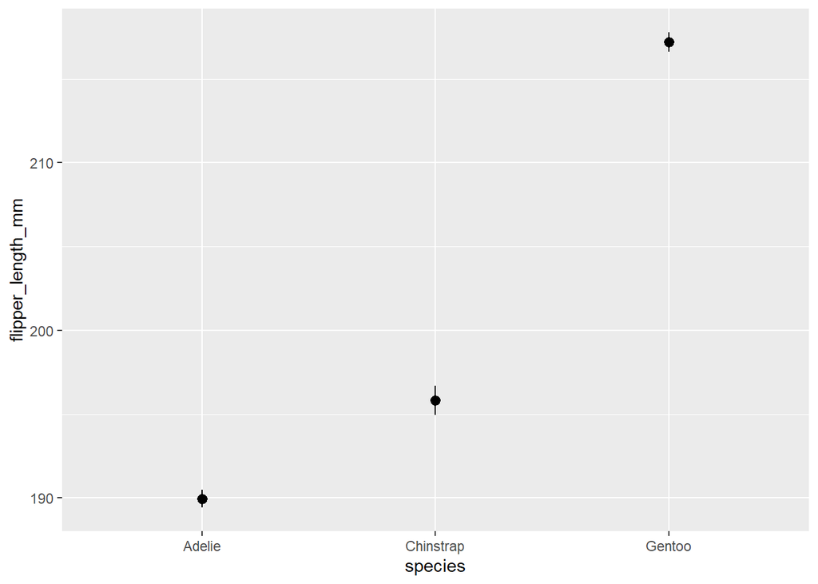

```r
penguins %>%
  ggplot(aes(x = species, y = flipper_length_mm)) +
  stat_summary()
```

To add the significance levels of the tests performed, I used the `geom_signif()` layer provided by the `ggsignif` package.

Since I performed two different tests (t-test for the comparison of Chinstrap and Adelie penguins, Wilcoxon test for the other two comparisons), I added two different significance layers that distinguish the two tests.

For the boxplot:

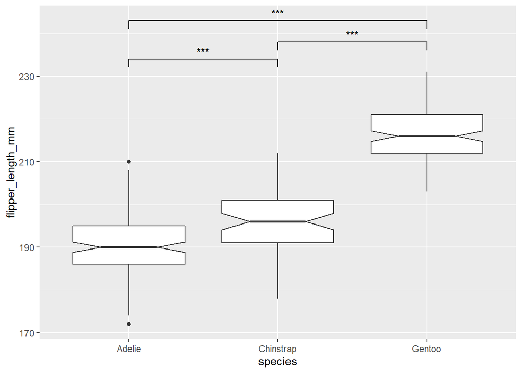

```r
library(ggsignif)
penguins %>%
  ggplot(aes(x = species, y = flipper_length_mm)) +
  geom_boxplot(notch = TRUE) +
  geom_signif(
    comparisons = list(
      c("Chinstrap", "Adelie")
    ),
    test = "t.test",
    test.args = list(var.equal = TRUE),
    map_signif_level = TRUE
  ) +
  geom_signif(
    comparisons = list(
      c("Chinstrap", "Gentoo"),
      c("Gentoo", "Adelie")
    ),
    test = "wilcox.test",
    y_position = c(235, 240),
    map_signif_level = TRUE
  )
```

For a plot with mean and errorbar:

```
## No summary function supplied, defaulting to `mean_se()`
```

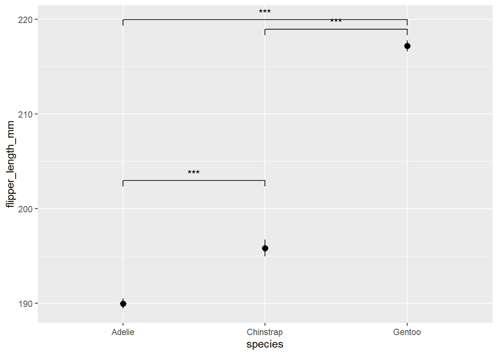

```r
penguins %>%
  ggplot(aes(x = species, y = flipper_length_mm)) +
  stat_summary() +
  geom_signif(
    comparisons = list(
      c("Chinstrap", "Adelie")
    ),
    test = "t.test",
    test.args = list(var.equal = TRUE),
    map_signif_level = TRUE,
    y_position = 200,
    tip_length = 0.01
  ) +
  geom_signif(
    comparisons = list(
      c("Chinstrap", "Gentoo"),
      c("Gentoo", "Adelie")
    ),
    test = "wilcox.test",
    y_position = c(216, 217),
    map_signif_level = TRUE,
    tip_length = 0.01
  )
```